# Clean Hands, Healthy Lives: The Global Healthcare Hygiene Crisis

A UNICEF Data Report on Health Facility Sanitation

Author

Vaishnav Venugopal Nedungadi

Published

April 14, 2026

```python
from google.colab import drive
drive.mount('/content/drive')
```

## 1 Introduction

Imagine visiting a hospital or clinic expecting care — only to find it **lacks basic cleaning services**. No soap. No clean water. No sanitation. This is not a rare edge case: it is the daily reality for millions of people across the developing world.

This report analyses **UNICEF data on the proportion of health care facilities with no cleaning service**, a critical yet underreported indicator of global health infrastructure. When a health facility cannot maintain basic hygiene, it becomes a place that spreads disease rather than preventing it.

> *“Clean water, sanitation, and hygiene are the foundations of health. Without them, even the best medical staff cannot protect patients from infection.”*

The consequences are severe:

- **Increased risk** of healthcare-associated infections (HAIs)
- **Deterrence** of patients who avoid facilities they distrust
- **Disproportionate impact** on women giving birth and newborns
- **Undermining** of vaccination campaigns and treatment programmes

Using UNICEF’s indicator data combined with World Bank economic and demographic metadata, this report maps the crisis, tracks trends over time, and examines how a country’s wealth and population size relate to its health facility cleanliness.

[output not shown]

```python
import polars as pl
from plotnine import (
    ggplot, aes, geom_col, geom_point, geom_line, geom_smooth,
    geom_map, labs, theme, theme_minimal, theme_bw, theme_classic,
    element_text, element_blank, element_rect, element_line,
    scale_fill_gradient, scale_fill_manual, scale_color_manual,
    scale_x_continuous, scale_y_continuous,
    coord_flip, guides, guide_legend,
    facet_wrap
)
import geopandas as gpd
import warnings
warnings.filterwarnings('ignore')

print("Libraries loaded successfully.")
```

```
Libraries loaded successfully.
```

## 2 Data Loading and Exploration

We load three datasets provided by UNICEF:

1. **`unicef_indicator_1.csv`** — Proportion of health care facilities with no cleaning service (our primary indicator)
2. **`unicef_indicator_2.csv`** — HIV testing coverage for infants (supplementary indicator)
3. **`unicef_metadata.csv`** — Country-level economic and demographic metadata (World Bank indicators)

We join these datasets on country codes to enrich our analysis with GDP, population, and life expectancy data.

```python
# Load datasets using polars
indicator1 = pl.read_csv(
    "/content/drive/MyDrive/Colab Notebooks/unicef_indicator_1.csv"
)

indicator2 = pl.read_csv(
    "/content/drive/MyDrive/Colab Notebooks/unicef_indicator_2.csv"
)

metadata = pl.read_csv(
    "/content/drive/MyDrive/Colab Notebooks/unicef_metadata.csv"
)

# Basic data inspection
print(f"Indicator 1 shape: {indicator1.shape}")
print(f"Indicator 2 shape: {indicator2.shape}")
print(f"Metadata shape: {metadata.shape}")

print("\nIndicator 1 columns:", indicator1.columns)
print("\nMetadata columns:", metadata.columns)
```

```
Indicator 1 shape: (458, 14)
Indicator 2 shape: (970, 14)
Metadata shape: (13715, 15)

Indicator 1 columns: ['country', 'alpha_2_code', 'alpha_3_code', 'numeric_code', 'indicator', 'time_period', 'obs_value', 'sex', 'unit_multiplier', 'unit_of_measure', 'observation_status', 'observation_confidentaility', 'time_period_activity_related_to_when_the_data_are_collected', 'current_age']

Metadata columns: ['country', 'alpha_2_code', 'alpha_3_code', 'numeric_code', 'year', 'Population, total', 'GDP per capita (constant 2015 US$)', 'GNI (current US$)', 'Inflation, consumer prices (annual %)', 'Life expectancy at birth, total (years)', 'Military expenditure (% of GDP)', 'Fossil fuel en…
```

```python
# Exploratory data analysis
print("=== Indicator 1 Descriptive Statistics ===")
print(indicator1.describe())

print("\n=== Countries in dataset ===")
print(indicator1.select(pl.col("country")).unique().sort("country"))

print("\n=== Year range ===")
print(indicator1.select(pl.col("time_period").min().alias("min_year"),
                        pl.col("time_period").max().alias("max_year")))
```

```
=== Indicator 1 Descriptive Statistics ===
shape: (9, 15)
┌───────────┬──────────┬───────────┬───────────┬───┬───────────┬───────────┬───────────┬───────────┐
│ statistic ┆ country  ┆ alpha_2_c ┆ alpha_3_c ┆ … ┆ observati ┆ observati ┆ time_peri ┆ current_a │
│ ---       ┆ ---      ┆ ode       ┆ ode       ┆   ┆ on_status ┆ on_confid ┆ od_activi ┆ ge        │
│ str       ┆ str      ┆ ---       ┆ ---       ┆   ┆ ---       ┆ entaility ┆ ty_relate ┆ ---       │
│           ┆          ┆ str       ┆ str       ┆   ┆ str       ┆ ---       ┆ d_t…      ┆ str       │
│           ┆          ┆           ┆           ┆   ┆           ┆ str       ┆ ---       ┆           │
│           ┆          ┆           ┆           ┆   ┆           ┆           ┆ str       ┆           │
╞═══════════╪══════════╪═══════════╪═══════════╪═══╪═══════════╪═══════════╪═══════════╪═══════════╡
│ count     ┆ 458      ┆ 458       ┆ 458       ┆ … ┆ 0         ┆ 0         ┆ 0         ┆ 458       │
│ null_coun ┆ 0        ┆ 0         ┆ 0         ┆ … ┆ 458       ┆ 458       ┆ 458       ┆ 0         │
│ t         ┆          ┆           ┆           ┆   ┆           ┆           ┆           ┆           │
│ mean      ┆ null     ┆ null      ┆ null      ┆ … ┆ null      ┆ null      ┆ null      ┆ null      │
│ std       ┆ null     ┆ null      ┆ null      ┆ … ┆ null      ┆ null      ┆ null      ┆ null      │
│ min       ┆ Bhutan   ┆ BT        ┆ BTN       ┆ … ┆ null      ┆ null      ┆ null      ┆ Total     │
│ 25%       ┆ null     ┆ null      ┆ null      ┆ … ┆ null      ┆ null      ┆ null      ┆ null      │
│ 50%       ┆ null     ┆ null      ┆ null      ┆ … ┆ null      ┆ null      ┆ null      ┆ null      │
│ 75%       ┆ null     ┆ null      ┆ null      ┆ … ┆ null      ┆ null      ┆ null      ┆ null      │
│ max       ┆ Zimbabwe ┆ ZW        ┆ ZWE       ┆ … ┆ null      ┆ null      ┆ null      ┆ Total     │
└───────────┴──────────┴───────────┴───────────┴───┴───────────┴───────────┴───────────┴───────────┘

=== Countries in dataset ===
shape: (42, 1)
┌───────────────┐
│ country       │
│ ---           │
│ str           │
╞═══════════════╡
│ Bhutan        │
│ Cambodia      │
│ Croatia       │
│ Georgia       │
│ Guinea-Bissau │
│ …             │
│ Thailand      │
│ Tunisia       │
│ Uganda        │
│ Vanuatu       │
│ Zimbabwe      │
└───────────────┘

=== Year range ===
shape: (1, 2)
┌──────────┬──────────┐
│ min_year ┆ max_year │
│ ---      ┆ ---      │
│ i64      ┆ i64      │
╞══════════╪══════════╡
│ 2000     ┆ 2023     │
└──────────┴──────────┘
```

```python
# ── 1. Filter indicator 1 to 'Total' sex (avoid double-counting)
ind1_total = (
    indicator1
    .filter(pl.col("sex") == "Total")
    .select(
        pl.col("country"),
        pl.col("alpha_3_code"),
        pl.col("time_period").alias("year"),
        pl.col("obs_value").alias("pct_no_cleaning")
    )
)

# ── 2. Compute most-recent value per country for the world map
latest_by_country = (
    ind1_total
    .group_by(pl.col("country"), pl.col("alpha_3_code"))
    .agg(
        pl.col("pct_no_cleaning").last().alias("latest_pct"),
        pl.col("year").max().alias("latest_year")
    )
    .sort("latest_pct", descending=True)
)

print("Latest data per country:")
print(latest_by_country.head(10))

# ── 3. Join indicator 1 with metadata for scatterplot
metadata_clean = (
    metadata
    .select(
        pl.col("alpha_3_code"),
        pl.col("year"),
        pl.col("GDP per capita (constant 2015 US$)").alias("gdp_per_capita"),
        pl.col("Population, total").alias("population"),
        pl.col("Life expectancy at birth, total (years)").alias("life_expectancy")
    )
    .filter(pl.col("gdp_per_capita").is_not_null())
)

# Join on alpha_3_code and year
merged = (
    ind1_total
    .join(
        metadata_clean,
        on=["alpha_3_code", "year"],
        how="inner"
    )
    .filter(pl.col("pct_no_cleaning").is_not_null())
    .filter(pl.col("gdp_per_capita").is_not_null())
)

print(f"\nMerged dataset rows: {merged.shape[0]}")

# ── 4. Average per year for time-series chart
avg_per_year = (
    ind1_total
    .group_by(pl.col("year"))
    .agg(pl.col("pct_no_cleaning").mean().alias("avg_pct"))
    .sort("year")
)

# ── 5. Bar chart data – top 15 worst countries (latest value)
top15 = latest_by_country.head(15)

print("\nTop 15 countries by % facilities with no cleaning:")
print(top15)
```

```
Latest data per country:
shape: (10, 4)
┌──────────────────────┬──────────────┬────────────┬─────────────┐
│ country              ┆ alpha_3_code ┆ latest_pct ┆ latest_year │
│ ---                  ┆ ---          ┆ ---        ┆ ---         │
│ str                  ┆ str          ┆ f64        ┆ i64         │
╞══════════════════════╪══════════════╪════════════╪═════════════╡
│ Nepal                ┆ NPL          ┆ 83.7563    ┆ 2023        │
│ Vanuatu              ┆ VUT          ┆ 81.1321    ┆ 2023        │
│ Sudan                ┆ SDN          ┆ 78.209     ┆ 2023        │
│ Guinea-Bissau        ┆ GNB          ┆ 76.0479    ┆ 2023        │
│ Kenya                ┆ KEN          ┆ 75.3394    ┆ 2022        │
│ Morocco              ┆ MAR          ┆ 75.3043    ┆ 2023        │
│ Syrian Arab Republic ┆ SYR          ┆ 64.1115    ┆ 2023        │
│ Somalia              ┆ SOM          ┆ 62.7962    ┆ 2023        │
│ Solomon Islands      ┆ SLB          ┆ 62.1212    ┆ 2023        │
│ Bhutan               ┆ BTN          ┆ 55.0       ┆ 2023        │
└──────────────────────┴──────────────┴────────────┴─────────────┘

Merged dataset rows: 457

Top 15 countries by % facilities with no cleaning:
shape: (15, 4)
┌───────────────┬──────────────┬────────────┬─────────────┐
│ country       ┆ alpha_3_code ┆ latest_pct ┆ latest_year │
│ ---           ┆ ---          ┆ ---        ┆ ---         │
│ str           ┆ str          ┆ f64        ┆ i64         │
╞═══════════════╪══════════════╪════════════╪═════════════╡
│ Nepal         ┆ NPL          ┆ 83.7563    ┆ 2023        │
│ Vanuatu       ┆ VUT          ┆ 81.1321    ┆ 2023        │
│ Sudan         ┆ SDN          ┆ 78.209     ┆ 2023        │
│ Guinea-Bissau ┆ GNB          ┆ 76.0479    ┆ 2023        │
│ Kenya         ┆ KEN          ┆ 75.3394    ┆ 2022        │
│ …             ┆ …            ┆ …          ┆ …           │
│ Zimbabwe      ┆ ZWE          ┆ 54.0       ┆ 2023        │
│ Rwanda        ┆ RWA          ┆ 50.4333    ┆ 2023        │
│ Pakistan      ┆ PAK          ┆ 39.1542    ┆ 2023        │
│ Iraq          ┆ IRQ          ┆ 38.4106    ┆ 2023        │
│ Nicaragua     ┆ NIC          ┆ 38.172     ┆ 2023        │
└───────────────┴──────────────┴────────────┴─────────────┘
```

## 3 The Global Picture

### 3.1 A World Map of Health Facility Hygiene

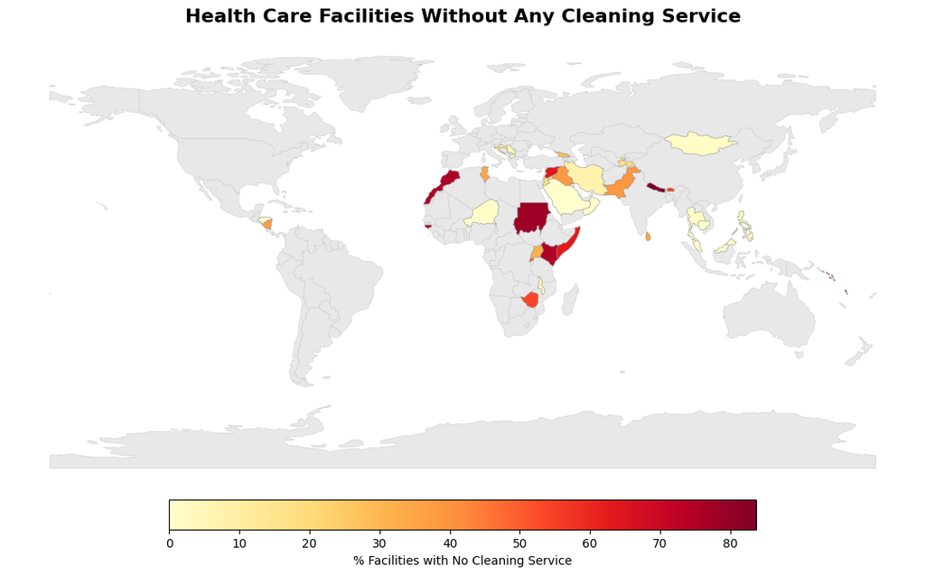

```
World map rendered.
```

```python
import geopandas as gpd # Import geopandas as gpd
import matplotlib.pyplot as plt
import matplotlib.colors as mcolors
import pandas as pd # Still needed for .to_pandas() and pl.from_pandas
import polars as pl # Ensure polars is imported for from_pandas

#| label: fig-world-map
#| fig-cap: "Proportion of health care facilities with no cleaning service (latest available year per country). Darker red indicates higher proportions."
#| fig-width: 12
#| fig-height: 6
#| warning: false

# Load world geometries from the manually downloaded and uploaded shapefile
world = gpd.read_file("/content/drive/MyDrive/Colab Notebooks/ne_110m_admin_0_countries/ne_110m_admin_0_countries.shp")

# Convert polars to pandas for geopandas merge
latest_pd = latest_by_country.to_pandas()

# Merge world shapes with UNICEF data on ISO alpha-3 codes
world_merged = world.merge(
    latest_pd[["alpha_3_code", "latest_pct"]],
    left_on="ADM0_A3", # Changed 'iso_a3' to 'ADM0_A3'
    right_on="alpha_3_code",
    how="left"
)

# Convert back to polars-compatible format for plotnine
# (Note: world_plot is not directly used by the matplotlib plot, but kept for consistency if needed later)
# world_plot = pl.from_pandas(
#     world_merged[["NAME", "ADM0_A3", "latest_pct", "geometry"]] # Changed 'name' to 'NAME' (capitalized) to match Natural Earth shapefile column
#     .assign(geometry=world_merged["geometry"])
# )

# Use geopandas + matplotlib for the world map since plotnine geom_map needs GeoDataFrame
fig, ax = plt.subplots(1, 1, figsize=(14, 7))

# Plot all countries in light grey first
world.plot(ax=ax, color="#e8e8e8", edgecolor="#cccccc", linewidth=0.4)

# Plot countries with data using a red colour scale
world_merged_data = world_merged.dropna(subset=["latest_pct"])
world_merged_data.plot(
    column="latest_pct",
    ax=ax,
    cmap="YlOrRd",
    edgecolor="#999999",
    linewidth=0.4,
    legend=True,
    legend_kwds={
        "label": "% Facilities with No Cleaning Service",
        "orientation": "horizontal",
        "shrink": 0.5,
        "pad": 0.02
    }
)

ax.set_title(
    "Health Care Facilities Without Any Cleaning Service",
    fontsize=16, fontweight="bold", pad=12
)
ax.set_axis_off()
plt.tight_layout()
plt.savefig("map_output.png", dpi=150, bbox_inches="tight")
plt.show()
print("World map rendered.")
```

### 3.2 The Worst Offenders: Country Rankings

The bar chart below ranks the **15 countries with the highest percentage of health facilities lacking cleaning services**. The results are striking: several countries exceed **50% of all facilities** — meaning that, on average, every other clinic or hospital has no cleaning service whatsoever.

This is not just a hygiene issue. It reflects **systemic underfunding of health infrastructure**, shortage of trained cleaning staff, and inadequate supply chains for basic cleaning materials like soap and disinfectant.

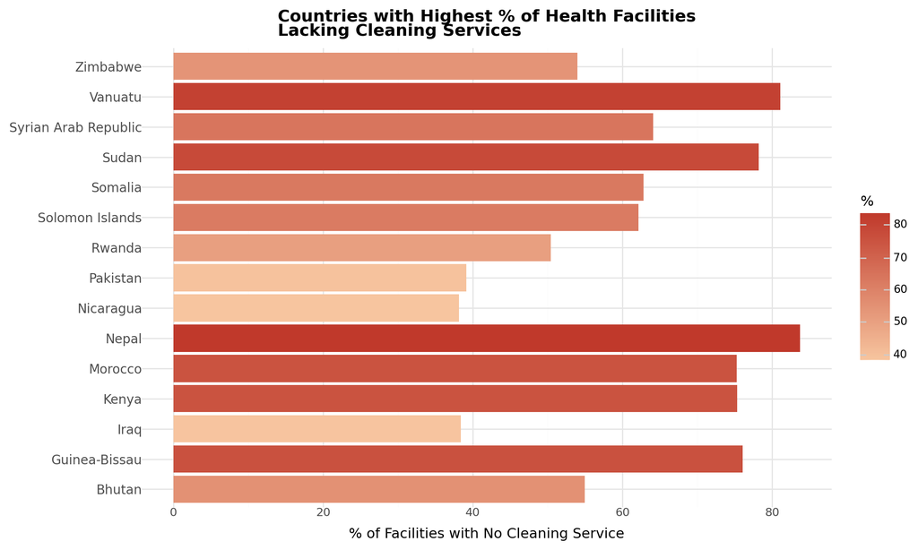

```python
# Prepare data: sort and convert for plotnine
top15_pd = top15.to_pandas()
top15_pd = top15_pd.sort_values("latest_pct", ascending=True)
top15_pl = pl.from_pandas(top15_pd)

(
    ggplot(
        top15_pl.to_pandas(),
        aes(x="country", y="latest_pct", fill="latest_pct")
    )
    + geom_col()
    + coord_flip()
    + scale_fill_gradient(low="#f7c59f", high="#c0392b")
    + labs(
        title="Countries with Highest % of Health Facilities\nLacking Cleaning Services",
        x="",
        y="% of Facilities with No Cleaning Service",
        fill="%"
    )
    + theme_minimal()
    + theme(
        plot_title=element_text(face="bold", size=13),
        axis_text_y=element_text(size=10),
        axis_text_x=element_text(size=9),
        figure_size=(10, 6)
    )
)
```

## 4 The Wealth Connection

### 4.1 Does GDP Predict Facility Hygiene?

A critical question is whether this crisis is **purely a resource problem** — i.e., do richer countries simply have cleaner facilities? The scatterplot below explores the relationship between **GDP per capita** and the **proportion of facilities lacking cleaning services**.

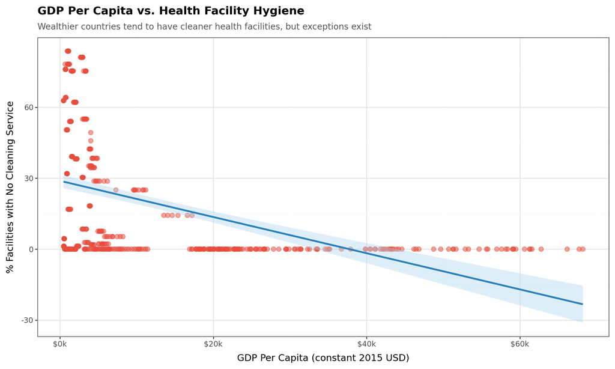

Figure 2: Relationship between GDP per capita (constant 2015 USD) and the proportion of health facilities with no cleaning service. Each point represents one country-year observation. The blue line shows the linear regression trend.

```python
merged_pd = merged.to_pandas()

(
    ggplot(
        merged_pd,
        aes(x="gdp_per_capita", y="pct_no_cleaning")
    )
    + geom_point(alpha=0.5, color="#e74c3c", size=2.5)
    + geom_smooth(method="lm", color="#2980b9", fill="#aed6f1", size=1.2)
    + scale_x_continuous(
        labels=lambda lst: [f"${int(x/1000)}k" for x in lst]
    )
    + labs(
        title="GDP Per Capita vs. Health Facility Hygiene",
        subtitle="Wealthier countries tend to have cleaner health facilities, but exceptions exist",
        x="GDP Per Capita (constant 2015 USD)",
        y="% Facilities with No Cleaning Service"
    )
    + theme_bw()
    + theme(
        plot_title=element_text(face="bold", size=13),
        plot_subtitle=element_text(color="#555555", size=10),
        figure_size=(10, 6)
    )
)
```

## 5 Tracking Change Over Time

### 5.1 Is the Situation Improving?

The time-series chart below tracks the **average percentage of health facilities without cleaning services** across all countries in the dataset from 2000 to the most recent available year.

The **COVID-19 pandemic** after 2020 likely placed additional strain on already-stretched health infrastructure, diverting resources away from routine maintenance and cleaning services.

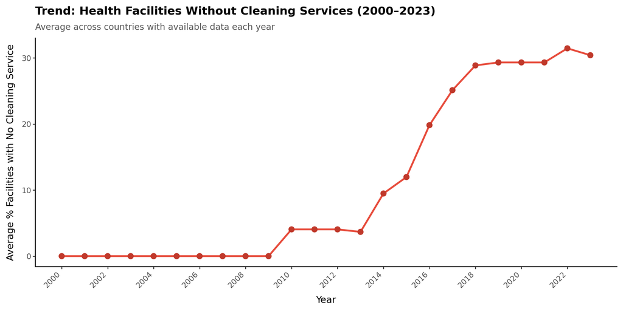

Figure 3: Average proportion of health care facilities with no cleaning service across all countries in the dataset, tracked over time (2000–2023). Countries with missing data for a given year are excluded from that year’s average.

```python
avg_pd = avg_per_year.to_pandas()

(
    ggplot(
        avg_pd,
        aes(x="year", y="avg_pct")
    )
    + geom_line(color="#e74c3c", size=1.2)
    + geom_point(color="#c0392b", size=3)
    + scale_x_continuous(
        breaks=list(range(2000, 2024, 2))
    )
    + labs(
        title="Trend: Health Facilities Without Cleaning Services (2000–2023)",
        subtitle="Average across countries with available data each year",
        x="Year",
        y="Average % Facilities with No Cleaning Service"
    )
    + theme_classic()
    + theme(
        plot_title=element_text(face="bold", size=13),
        plot_subtitle=element_text(color="#555555", size=10),
        axis_text_x=element_text(angle=45, hjust=1),
        figure_size=(10, 5)
    )
)
```

## 6 Conclusions and Call to Action

This report has presented four complementary views of a single, critical global health challenge: the **lack of cleaning services in health facilities** across the developing world.

### 6.2 What Must Be Done

Achieving **universal health coverage** — one of the UN Sustainable Development Goals — is impossible without clean health facilities. The following actions are urgently needed:

1. **Increased investment** in health facility infrastructure, specifically sanitation and hygiene services
2. **National hygiene standards** with independent monitoring and accountability mechanisms
3. **Training and employment** of dedicated health facility cleaners as part of the health workforce
4. **International partnerships** to supply cleaning materials, especially in fragile and conflict-affected states
5. **Data collection improvements** so that more countries can be tracked and held accountable

Clean facilities save lives. This is not a luxury — it is a **fundamental right** for every patient, everywhere.

*Data sources: UNICEF Global Databases; World Bank Development Indicators. Analysis conducted using Python (Polars, plotnine). Report generated with Quarto.*